# Kriging with GAM method

Octavio Mercado Peña

20/03/2023

This workflow consists in creating equispaced gridded data layers by interpolating discrete spatial measurements of oceanographic variables such as temperature, salinity, oxygen and density. This was done with the regression-kriging spatial prediction technique, using an ordinary kriging and generalized additive model (GAM) available as libraries in R, developed by Pebesma, E. 2004 and Simon Wood (see Wood, S.N. 2017), respectively. As an example, in situ temperature at 10 m depth was used for each of the profiles collected during the “MOBIO-MPH 2020” cruise, conducted by the Instituto de Fomento Pesquero (IFOP) between September and October 2020 on board the vessel Abate Molina. This as part of the research project “Coupling oceanographic and habitat models to assess abundance, distribution, and risk for baleen whales in Chile: Developing new tools for management” undertaken by researchers from Universidad Austral de Chile, Universidad de Valparaíso, Universidad de Concepción, Centro de Investigación Oceanográfica en el Pacífico Sur Oriental (COPAS Coastal), IFOP, Centro de Estudios Avanzados en Zonas Áridas, Scripps Institute of Oceanography, Oregon State University and ENSTA Bretagne. Funded by COPAS Coastal HIT projects 2022.

```
Load required libraries
```

```r
library(sp)
library(gstat)
library(dplyr)
library(ggplot2)
library(scales)
library(magrittr)
library(geosphere)
library(rgeos)
library(raster)
library(rgdal)
library(dismo)
library(sf)
library(tmap)
library(tmaptools)
library(maptiles)
library(mgcv)
library(readr)
library(readxl)
library(rJava)
library(OpenStreetMap)
library(corrplot)
library(rerddap)
library(rerddapXtracto)
RMSE <- function(observed, predicted) {
  sqrt(mean((predicted - observed)^2, na.rm=TRUE))
}
```

```
Load our sampling units data
```

```r
MOBIO2020=read_xlsx("OCE_MOBIO_MPH-2020_646.xlsx",col_names = TRUE)
data2020 <- MOBIO2020[c("lat(°S)","min Lat","long(°W)","min long","profundidad (m)","temp (°C)")]
colnames(data2020) <- c("Latitude","min.lat","Longitude","min.long","Depth","Temperature")
data2020$Latitude <- -data2020$Latitude - data2020$min.lat/60; data2020$Longitude <- -data2020$Longitude - data2020$min.long/60
data2020 <- data2020[,c("Latitude","Longitude","Depth","Temperature")]
data2020=data2020[complete.cases(data2020),]
```

```
Dataset from ETOPO1 and layer of interest
```

```r
profInfo <- rerddap::info("etopo360") # extracts information about ETOPO1 topography
dp = 10 # Layer of interest
pos <- which(data2020$Depth == dp) # find positions at 10 meters
data <- data2020[pos,]
```

```
Coordinates transform
```

```r
coord_data2020 = data.frame(Longitude=data$Longitude,Latitude=data$Latitude)
coordinates(coord_data2020) <- ~ Longitude + Latitude
crs(coord_data2020)= "+proj=longlat +datum=WGS84 +no_defs +ellps=WGS84 +towgs84=0,0,0" # assigns a coordinate reference system
UTMcoord_data2020=spTransform(coord_data2020,CRS("+proj=utm +zone=18 +south +datum=WGS84 +units=m +no_defs +ellps=WGS84 +towgs84=0,0,0")) # transform to UTM coordinates (X,Y)
```

```
Add X,Y coordinates and transform into a SpatialPointsDataFrame
```

```r
data$X <- as.numeric(UTMcoord_data2020@coords[,1])
data$Y <- as.numeric(UTMcoord_data2020@coords[,2])
pdata=st_as_sf(data, coords = c("Longitude","Latitude"), crs = 4326)
coordinates(data) <- ~ X + Y
```

```
Set projection
```

```r
crs(data) = "+proj=utm +zone=18 +south +datum=WGS84 +units=m +no_defs +ellps=WGS84 +towgs84=0,0,0"
```

```
Generate visualization of the data
```

```r
prov_maptiles = names(maptiles:::maptiles_providers)
```

```r
tmap_mode('view')
```

```r
tm_shape(pdata) +
  tm_basemap(server = "Esri.WorldImagery")+
  tm_dots(col = "Temperature", size = 0.1)
```

[interactive chart not shown]

```
Generate empty raster for interpolation, but first create a convex hull around sampling points
```

```r
data2020_r=chull(data@coords)
data2020_r <- data@coords[c(data2020_r, data2020_r[1]), ]
data2020_r=SpatialPolygons(list(Polygons(list(Polygon(data2020_r)), ID=1)))
```

```
Set a buffer area of 2.5km around the polygon
```

```r
data2020_r=gBuffer(data2020_r,width = 2500)
```

```
Create and empty raster based on this buffered area
```

```r
data2020_rv <- raster(extent(data2020_r),res = 7000) # Grid resolution (7km)
data2020_r <- rasterize(data2020_r, data2020_rv, fun = "last")
crs(data2020_r)="+proj=utm +zone=18 +south +datum=WGS84 +units=m +no_defs +ellps=WGS84 +towgs84=0,0,0"
coord_data2020_r<- xyFromCell(data2020_r,1:ncell(data2020_r))
coord_data2020_r=data.frame(X=coord_data2020_r[,1],Y=coord_data2020_r[,2])
coordinates(coord_data2020_r) <- ~ X + Y
crs(coord_data2020_r)="+proj=utm +zone=18 +south +datum=WGS84 +units=m +no_defs +ellps=WGS84 +towgs84=0,0,0"
llcoord_data2020_r=spTransform(coord_data2020_r,CRS("+proj=longlat +datum=WGS84 +no_defs +ellps=WGS84 +towgs84=0,0,0"))
```

```
Download depth values for the study area
```

```r
prof <- rerddapXtracto::rxtracto(profInfo, parameter = 'altitude', xcoord = llcoord_data2020_r@coords[,1], ycoord = llcoord_data2020_r@coords[,2], tcoord = NULL, zcoord = NULL, xlen = 0, ylen = 0)
depthN=raster(matrix(prof$`mean altitude`,ncol =ncol(data2020_r),nrow =nrow(data2020_r),byrow = T))
depthN=setExtent(depthN,extent(data2020_r)) # Set the data to "extent" area
```

```
Earth mask and set cells with NA
```

```r
depthN=mask(depthN,data2020_r)
depthN[depthN>0]=NA
rx=ry=depthN
xy<-xyFromCell(depthN,1:length(depthN))
rx[]<-xy[,1] #raster of Easting (Longitudee)
ry[]<-xy[,2] #raster of Northing (Latitudee)
rx=mask(rx,depthN)#use depth layer to set NA to those cells outside buffer area and in land
ry=mask(ry,depthN)
crs(depthN)="+proj=utm +zone=18 +south +datum=WGS84 +units=m +no_defs +ellps=WGS84 +towgs84=0,0,0"
crs(rx)="+proj=utm +zone=18 +south +datum=WGS84 +units=m +no_defs +ellps=WGS84 +towgs84=0,0,0"
crs(ry)="+proj=utm +zone=18 +south +datum=WGS84 +units=m +no_defs +ellps=WGS84 +towgs84=0,0,0"
rst_layers=stack(c(depthN,rx,ry))
names(rst_layers) <- c("depth", "X", "Y")
```

```
Plot spatial variability
```

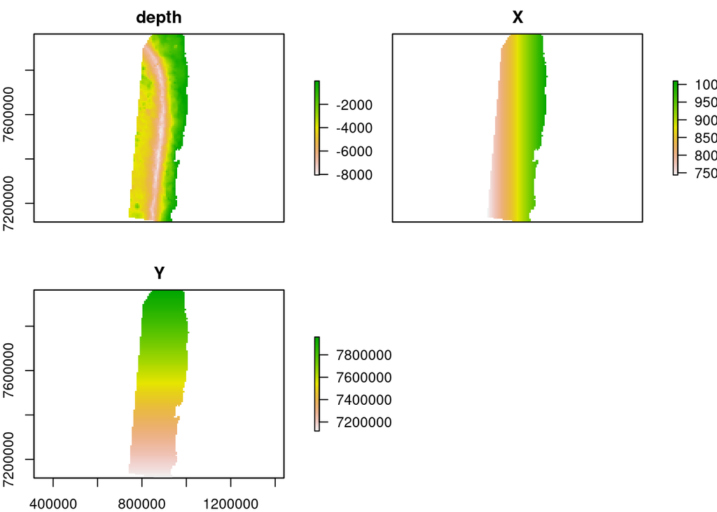

```r
plot(rst_layers)
```

```r
prof2 <- rerddapXtracto::rxtracto(profInfo, parameter = 'altitude', xcoord = data$Longitude, ycoord = data$Latitude, tcoord = NULL, zcoord = NULL, xlen = 0, ylen = 0)
data$depth=prof2$`mean altitude`
```

```
Check for correlations in data
```

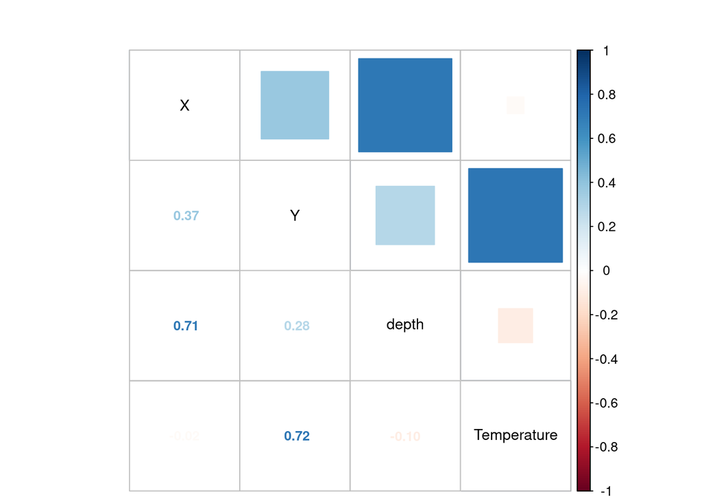

```
Fit a variogram for the data
In this case use depth, Easting and Northing as covariates
```

```r
corMat <- cor(data.frame(X=data@coords[,1],Y=data@coords[,2],depth=data$depth,Temperature = data$Temperature))
corrplot::corrplot.mixed(corMat, number.cex=0.8, tl.cex = 0.9, tl.col = "black",
                         outline=FALSE, mar=c(0,0,2,2), upper="square", bg=NA)
```

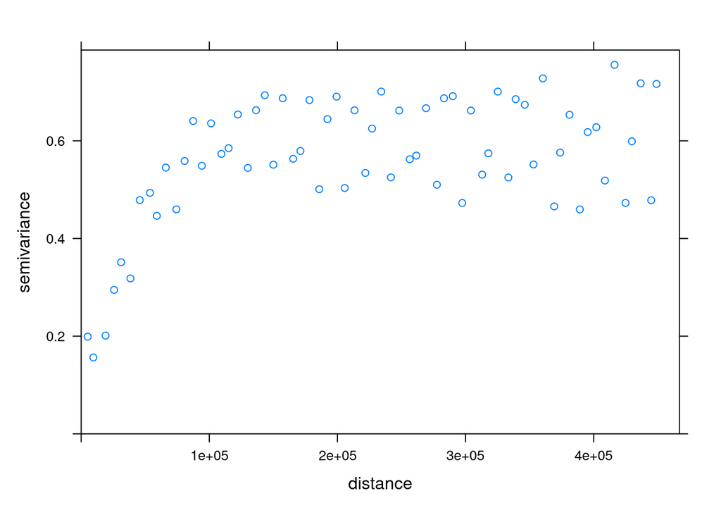

```
Modified Variogram
```

```r
gs <- gstat(formula=Temperature~Y+depth+X, locations=data)
v <- variogram(gs,width=7000,cutoff=450000)
plot(v)
```

```r
vmod <- vgm(psill=max(v$gamma), model="Exp", range=130000,nugget=min(v$gamma))
```

```
Variogram fitting by Ordinary Least Square
```

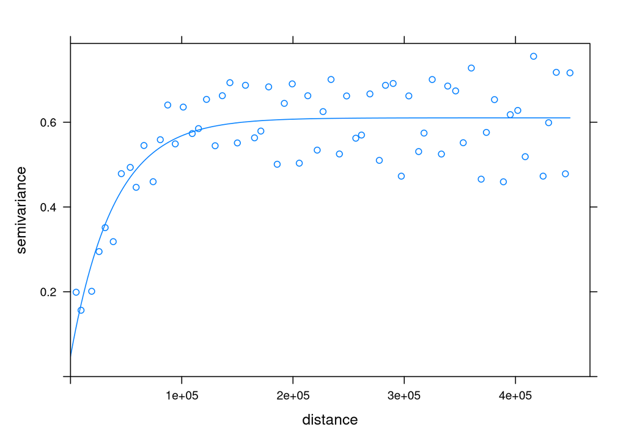

```
k-fold Cross validation (with k = 10) to determine the best fit with Kriging
```

```r
fvmod <- fit.variogram(v, model=vmod,fit.method = 6)
plot(v,fvmod)
```

```r
k=10
evalData <- matrix(NA,nrow = k, ncol = 7,
                   dimnames = list(1:k,c("OKall","OKY","OKX","OKdp","OKYX","OKYdp","OKXdp")))
kf_data <- kfold(nrow(data),k)

for (i in 1:k) {
  cat("K-fold...",i,"of",k,"....\n")

  test <- data[kf_data == i, ]
  train <- data[kf_data != i, ]


  # All coordinates variogram

  gs <- gstat(formula=Temperature~Y + X + depth, locations=train)
  v <- variogram(gs,width=7000)
  vmod <- vgm(psill=max(v$gamma), model="Exp", range=150000,nugget=min(v$gamma))
  fvmod <- fit.variogram(v, model=vmod,fit.method = 6)
  plot(v,fvmod,cutoff = 450000)

  # Regression Kriging

  OKall <- krige(formula = gs$data$var1$formula,
                 locations = train,
                 model = fvmod,
                 newdata = test,
                 debug.level = 0)
  okall.pred.test <- OKall@data$var1.pred
  evalData[i,"OKall"]<-RMSE(test$Temperature,okall.pred.test)

  # Y coordinate variogram

  gsY <- gstat(formula=Temperature~Y, locations=train)
  vY <- variogram(gsY,width=7000)
  vmodY <- vgm(psill=max(vY$gamma), model="Exp", range=200000,nugget=min(vY$gamma))
  fvmodY <- fit.variogram(vY, model=vmodY,fit.method = 6)
  plot(vY,fvmodY,cutoff = 450000)

  # Regression Kriging

  OKY <- krige(formula = gsY$data$var1$formula,
               locations = train,
               model = fvmodY,
               newdata = test,
               debug.level = 0)
  okY.pred.test <- OKY@data$var1.pred
  evalData[i,"OKY"]<-RMSE(test$Temperature,okY.pred.test)

  # X coordinate variogram

  gsX <- gstat(formula=Temperature~X, locations=train)
  vX <- variogram(gsX,width=7000)
  vmodX <- vgm(psill=max(vX$gamma), model="Exp", range=100000,nugget=min(vX$gamma))
  fvmodX <- fit.variogram(vX, model=vmodX,fit.method = 6)
  plot(vX,fvmodX,cutoff = 200000)

  # Regression Kriging

  OKX <- krige(formula = gsX$data$var1$formula,
               locations = train,
               model = fvmodX,
               newdata = test,
               debug.level = 0)
  okX.pred.test <- OKX@data$var1.pred
  evalData[i,"OKX"]<-RMSE(test$Temperature,okX.pred.test)

  # Depth coordinate variogram

  gsdp <- gstat(formula=Temperature~depth, locations=train)
  vdp <- variogram(gsdp,width=7000)
  vmoddp <- vgm(psill=max(vdp$gamma), model="Exp", range=130000,nugget=min(vdp$gamma))
  fvmoddp <- fit.variogram(vdp, model=vmoddp,fit.method = 6)
  plot(vdp,fvmoddp,cutoff = 200000)

  # Regression Kriging

  OKdp <- krige(formula = gsdp$data$var1$formula,
                locations = train,
                model = fvmoddp,
                newdata = test,
                debug.level = 0)
  okdp.pred.test <- OKdp@data$var1.pred
  evalData[i,"OKdp"]<-RMSE(test$Temperature,okdp.pred.test)

  # Y-X coordinate variogram

  gsYX <- gstat(formula=Temperature~Y+X, locations=train)
  vYX <- variogram(gsYX,width=7000)
  vmodYX <- vgm(psill=max(vYX$gamma), model="Exp", range=150000,nugget=min(vYX$gamma))
  fvmodYX <- fit.variogram(vYX, model=vmodYX,fit.method = 6)
  plot(vYX,fvmodYX,cutoff = 450000)

  # Regression Kriging

  OKYX <- krige(formula = gsYX$data$var1$formula,
                locations = train,
                model = fvmodYX,
                newdata = test,
                debug.level = 0)
  okYX.pred.test <- OKYX@data$var1.pred
  evalData[i,"OKYX"]<-RMSE(test$Temperature,okYX.pred.test)

  # Y-depth coordinate variogram

  gsYdp <- gstat(formula=Temperature~Y+depth, locations=train)
  vYdp <- variogram(gsYdp,width=7000)
  vmodYdp <- vgm(psill=max(vYdp$gamma), model="Exp", range=150000,nugget=min(vYdp$gamma))
  fvmodYdp <- fit.variogram(vYdp, model=vmodYdp,fit.method = 6)
  plot(vYdp,fvmodYdp,cutoff = 450000)

  # Regression Kriging

  OKYdp <- krige(formula = gsYdp$data$var1$formula,
                 locations = train,
                 model = fvmodYdp,
                 newdata = test,
                 debug.level = 0)
  okYdp.pred.test <- OKYdp@data$var1.pred
  evalData[i,"OKYdp"]<-RMSE(test$Temperature,okYdp.pred.test)

  # X-depth coordinate variogram

  gsXdp <- gstat(formula=Temperature~X+depth, locations=train)
  vXdp <- variogram(gsXdp,width=7000)
  vmodXdp <- vgm(psill=max(vXdp$gamma), model="Exp", range=130000,nugget=min(vXdp$gamma))
  fvmodXdp <- fit.variogram(vXdp, model=vmodXdp,fit.method = 6)
  plot(vXdp,fvmodXdp,cutoff = 200000)

  # Regression Kriging

  OKXdp <- krige(formula = gsXdp$data$var1$formula,
                 locations = train,
                 model = fvmodXdp,
                 newdata = test,
                 debug.level = 0)
  okXdp.pred.test <- OKXdp@data$var1.pred
  evalData[i,"OKXdp"]<-RMSE(test$Temperature,okXdp.pred.test)
}
```

```
## K-fold... 1 of 10 ....
## K-fold... 2 of 10 ....
## K-fold... 3 of 10 ....
## K-fold... 4 of 10 ....
## K-fold... 5 of 10 ....
## K-fold... 6 of 10 ....
## K-fold... 7 of 10 ....
## K-fold... 8 of 10 ....
## K-fold... 9 of 10 ....
## K-fold... 10 of 10 ....
```

```r
round(apply(evalData,2,FUN = function(x,...) c(mean(x,...),sd(x,...))),3)
```

```
##      OKall   OKY   OKX  OKdp  OKYX OKYdp OKXdp
## [1,] 0.368 0.368 0.364 0.376 0.366 0.375 0.368
## [2,] 0.037 0.036 0.037 0.035 0.037 0.036 0.036
```

```
GAM method
We use the combination with a lower average RMSE
```

```r
GAM <- gam(formula = Temperature~ s(X), data = data)
summary(GAM)
```

```
##
## Family: gaussian
## Link function: identity
##
## Formula:
## Temperature ~ s(X)
##
## Parametric coefficients:
##             Estimate Std. Error t value Pr(>|t|)
## (Intercept) 15.85916    0.05143   308.4   <2e-16 ***
## ---
## Signif. codes:  0 '***' 0.001 '**' 0.01 '*' 0.05 '.' 0.1 ' ' 1
##
## Approximate significance of smooth terms:
##        edf Ref.df     F p-value
## s(X) 5.941  7.136 13.41  <2e-16 ***
## ---
## Signif. codes:  0 '***' 0.001 '**' 0.01 '*' 0.05 '.' 0.1 ' ' 1
##
## R-sq.(adj) =  0.157   Deviance explained = 16.7%
## GCV = 1.3541  Scale est. = 1.3355    n = 505
```

```r
rstPredGAM <- predict(rst_layers, GAM, type="response")
rstPixDF <- as(rst_layers[[1]], "SpatialPixelsDataFrame")
```

```
Create a temporary SpatialPointsDF object to store GAM residuals
```

```r
statPointsTMP <- data
crs(statPointsTMP) <- crs(rstPixDF)
statPointsTMP@data <- cbind(statPointsTMP@data, residGAM = resid(GAM))
```

```
Define the kriging parameters and fit the variogram using OLS
```

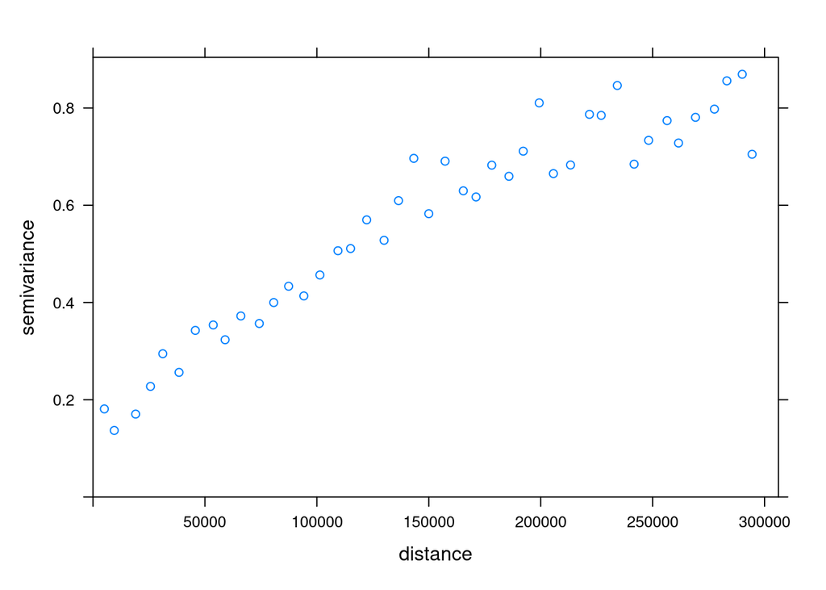

```
Choose the best-fit model
```

```r
formMod <- residGAM ~ 1
variog <- variogram(formMod, statPointsTMP,width = 7000) # 7 km distance (resolution grid)
plot(variog)
```

```r
vmod <- vgm(psill=max(variog$gamma), model=c("Sph","Exp","Lin","Gau"), range=120000,nugget=min(variog$gamma))
variogFitOLS <- fit.variogram(variog, model = vmod,  fit.method = 6)
variogFitOLS
```

```
##   model     psill    range
## 1   Exp 0.8710447 118427.6
```

```r
vmod <- vgm(psill=max(variog$gamma), model="Exp", range=120000,nugget=min(variog$gamma))
variogFitOLS <- fit.variogram(variog, model = vmod,  fit.method = 6)
```

```
Plot the results
```

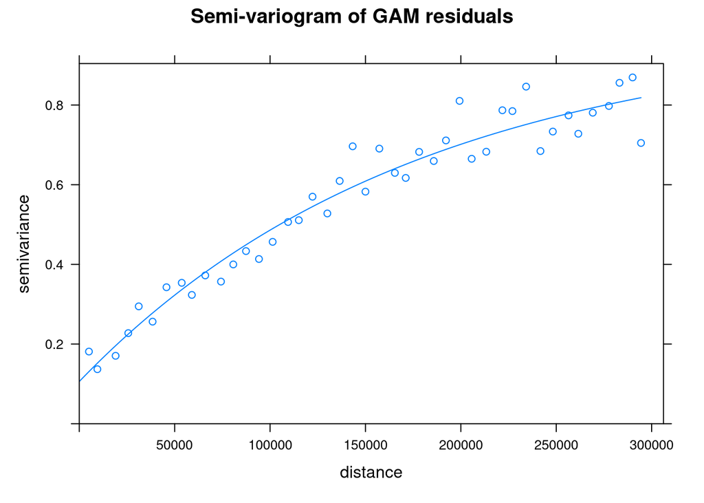

```
Interpolate residuals with kriging
```

```r
plot(variog, variogFitOLS, main="Semi-variogram of GAM residuals")
```

```r
residKrigMap <- krige(formula = formMod ,
                      locations = statPointsTMP,
                      model = variogFitOLS,
                      newdata = rstPixDF)
```

```
## [using ordinary kriging]
```

```r
residKrigRstLayer <- as(residKrigMap, "RasterLayer")
gamKrigMap <- rstPredGAM + residKrigRstLayer
```

```
Plot the resulting layer
```

```r
rst_pts <- rasterToPoints(gamKrigMap, spatial = TRUE)
rst_pts =spTransform(rst_pts,CRS("+proj=longlat +datum=WGS84 +no_defs +ellps=WGS84 +towgs84=0,0,0"))
```

```
Then to a 'conventional' dataframe
```

```r
rst_vars  <- data.frame(rst_pts)
names(rst_vars) <- c("Temperature","x","y")
```

```r
pal <- colorRampPalette(c("blue","cyan","green","yellow","red"))
```

```r
bio_map <- openmap(c(-26.2, -69.8), c(-18, -73), zoom = 10,
                   type = "bing", mergeTiles = TRUE)
```

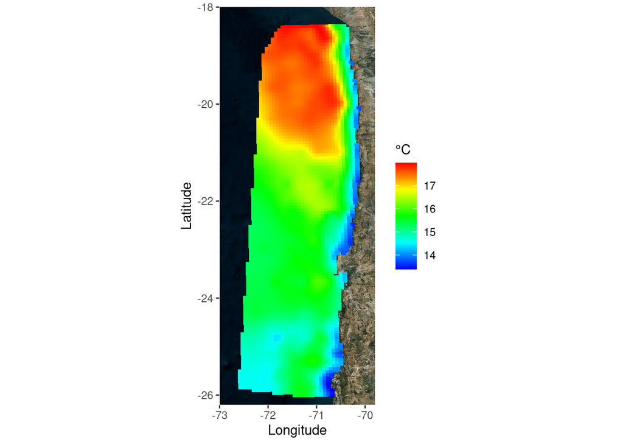

```r
bio_map2 <- openproj(bio_map)
bio_plt <- OpenStreetMap::autoplot.OpenStreetMap(bio_map2)+
  geom_point(data=rst_vars,shape=15,aes(colour = Temperature)) +
  labs(colour = "°C",x = "Longitude",y = "Latitude") +
  scale_colour_gradientn(colours = pal(50))
bio_plt
```